# Análise de Correlação entre Variáveis de Qualidade da Água

## Introdução

Este tutorial ensina a calcular e visualizar coeficientes de correlação de Spearman entre parâmetros de qualidade da água, precipitação e vazão, separados por períodos **chuvoso** e **seco**. O passo a passo é detalhado para permitir a reprodução com **outros conjuntos de dados**.

## 1. Preparar o Ambiente

### 1.1 Carregar os pacotes necessários

```r
if (!require("pacman")) install.packages("pacman")
library(pacman)
p_load(tidyverse, readxl, psych)
```

> 🔧 **Nota**: `pacman` instala automaticamente pacotes faltantes.

### 1.2 Definir o diretório de trabalho

```r
setwd("C:/Users/HP/OneDrive/Documentos/Doutorado/Tese/1) Dados")
```

> 🔧 **Altere o caminho conforme sua estrutura de pastas.**

## 2. Carregar os Dados do Excel

```r
dados <- read_excel("Dados_Ipojuca.xlsx", sheet = 1)
```

> 🔍 **Substitua o nome do arquivo conforme o seu.**

## 3. Verificar e Corrigir Tipos de Variáveis

Pode acontecer de o R não ler corretamente o tipo de variável adequado para a análise, como, por exemplo, não reconhecer uma variável numérica. Por isso, é importante sempre fazer uma verificação se os tipos de variáveis estão corretos para análise. A função **glimpse()** do tidyverse/dplyr permite a visualização de um resumo dos dados, mostrando o tipo de cada coluna.

```r
glimpse(dados)
```

```
## Rows: 461
## Columns: 22
## $ UA           <chr> "UA1", "UA1", "UA1", "UA1", "UA1", "UA1", "UA1", "UA1", "…
## $ Municipio    <chr> "Belo Jardim", "Belo Jardim", "Belo Jardim", "Belo Jardim…
## $ Estacao      <chr> "IP-12", "IP-12", "IP-12", "IP-12", "IP-12", "IP-12", "IP…
## $ Data         <dttm> 2005-04-27, 2005-10-19, 2006-04-26, 2006-10-05, 2007-04-…
## $ Mês          <chr> "Abril", "Outubro", "Abril", "Outubro", "Abril", "Outubro…
## $ Ano          <chr> "2005", "2005", "2006", "2006", "2007", "2007", "2008", "…
## $ Periodo      <chr> "Chuvoso", "Seco", "Chuvoso", "Seco", "Chuvoso", "Seco", …
## $ Periodo_real <chr> "Chuvoso", "Seco", "Chuvoso", "Seco", "Chuvoso", "Seco", …
## $ Precip_media <dbl> 74.70, 0.00, 54.00, 4.00, 37.50, 0.60, 80.35, 0.00, 0.00,…
## $ Vazao_media  <dbl> 0.0600, 0.0000, 0.7300, 0.0000, 0.1000, 0.0000, 9.0446, 0…
## $ Temp         <dbl> 30.0, 29.0, 25.0, 26.0, 28.0, 26.0, 27.0, 28.0, 27.0, 28.…
## $ pH           <dbl> 8.80, 7.40, 7.50, 8.60, 8.40, 8.30, 6.90, 7.80, 7.00, 7.0…
## $ Cond         <dbl> NA, 2418.0, 1731.0, 2925.0, 3253.0, 3344.0, 789.0, 2231.0…
## $ OD           <dbl> 11.00, 3.00, 5.00, 5.30, 5.00, 4.60, 4.80, 5.60, 1.00, 2.…
## $ DBO          <dbl> 6.4, 4.0, 2.2, 4.5, 5.7, 4.9, 3.7, 3.7, 3.0, 3.9, 1.2, 24…
## $ NH3          <dbl> 0.12, 0.12, 0.26, 0.12, 0.12, 0.14, 0.28, NA, 0.12, 0.12,…
## $ PT           <dbl> 0.190, 0.230, 0.270, 0.170, 0.270, 0.200, 1.320, 0.100, 0…
## $ Coli         <dbl> 200, 200, 1100, 200, 200, 200, 24000, 800, 400, 200, 200,…
## $ Sal          <chr> "1.2", "1.2", "0.9", "1.5", "1.7", "1.8", "0.4", "1.2", "…
## $ Turb         <dbl> NA, NA, NA, NA, NA, NA, NA, NA, NA, NA, NA, NA, NA, NA, N…
## $ Daphnia      <dbl> 1, 1, 1, 1, 1, 1, 1, 1, 1, 1, 1, 1, 1, 1, 1, 1, 1, NA, 1,…
## $ SDT          <dbl> NA, NA, NA, NA, NA, NA, NA, NA, NA, NA, NA, NA, NA, NA, N…
```

Neste caso, o R reconheceu a coluna **Sal** como tipo **character**. É necessário corrigir isso.

```r
# Transformar a coluna Sal para o tipo numérico
dados$Sal <- as.numeric(dados$Sal)
```

> ⚠️ **Corrija variáveis numéricas lidas como texto.**

Verifique o resumo dos dados novamente

```r
glimpse(dados)
```

```
## Rows: 461
## Columns: 22
## $ UA           <chr> "UA1", "UA1", "UA1", "UA1", "UA1", "UA1", "UA1", "UA1", "…
## $ Municipio    <chr> "Belo Jardim", "Belo Jardim", "Belo Jardim", "Belo Jardim…
## $ Estacao      <chr> "IP-12", "IP-12", "IP-12", "IP-12", "IP-12", "IP-12", "IP…
## $ Data         <dttm> 2005-04-27, 2005-10-19, 2006-04-26, 2006-10-05, 2007-04-…
## $ Mês          <chr> "Abril", "Outubro", "Abril", "Outubro", "Abril", "Outubro…
## $ Ano          <chr> "2005", "2005", "2006", "2006", "2007", "2007", "2008", "…
## $ Periodo      <chr> "Chuvoso", "Seco", "Chuvoso", "Seco", "Chuvoso", "Seco", …
## $ Periodo_real <chr> "Chuvoso", "Seco", "Chuvoso", "Seco", "Chuvoso", "Seco", …
## $ Precip_media <dbl> 74.70, 0.00, 54.00, 4.00, 37.50, 0.60, 80.35, 0.00, 0.00,…
## $ Vazao_media  <dbl> 0.0600, 0.0000, 0.7300, 0.0000, 0.1000, 0.0000, 9.0446, 0…
## $ Temp         <dbl> 30.0, 29.0, 25.0, 26.0, 28.0, 26.0, 27.0, 28.0, 27.0, 28.…
## $ pH           <dbl> 8.80, 7.40, 7.50, 8.60, 8.40, 8.30, 6.90, 7.80, 7.00, 7.0…
## $ Cond         <dbl> NA, 2418.0, 1731.0, 2925.0, 3253.0, 3344.0, 789.0, 2231.0…
## $ OD           <dbl> 11.00, 3.00, 5.00, 5.30, 5.00, 4.60, 4.80, 5.60, 1.00, 2.…
## $ DBO          <dbl> 6.4, 4.0, 2.2, 4.5, 5.7, 4.9, 3.7, 3.7, 3.0, 3.9, 1.2, 24…
## $ NH3          <dbl> 0.12, 0.12, 0.26, 0.12, 0.12, 0.14, 0.28, NA, 0.12, 0.12,…
## $ PT           <dbl> 0.190, 0.230, 0.270, 0.170, 0.270, 0.200, 1.320, 0.100, 0…
## $ Coli         <dbl> 200, 200, 1100, 200, 200, 200, 24000, 800, 400, 200, 200,…
## $ Sal          <dbl> 1.20, 1.20, 0.90, 1.50, 1.70, 1.80, 0.40, 1.20, 0.60, 1.1…
## $ Turb         <dbl> NA, NA, NA, NA, NA, NA, NA, NA, NA, NA, NA, NA, NA, NA, N…
## $ Daphnia      <dbl> 1, 1, 1, 1, 1, 1, 1, 1, 1, 1, 1, 1, 1, 1, 1, 1, 1, NA, 1,…
## $ SDT          <dbl> NA, NA, NA, NA, NA, NA, NA, NA, NA, NA, NA, NA, NA, NA, N…
```

## 4. Análises de Correlação

Agora que temos os tipos corretos de variáveis, podemos gerar os gráficos de correlação

### 4.1 Período Chuvoso

#### 4.1.1 Filtrar dados e renomear colunas, se necessário

```r
dados_chuvoso <- dados %>%
  filter(Estacao != "IP-97",
         Periodo_real == "Chuvoso") %>%
  rename("Precipitação" = "Precip_media",
         "Vazão" = "Vazao_media")
```

#### 4.1.2 Gerar gráfico

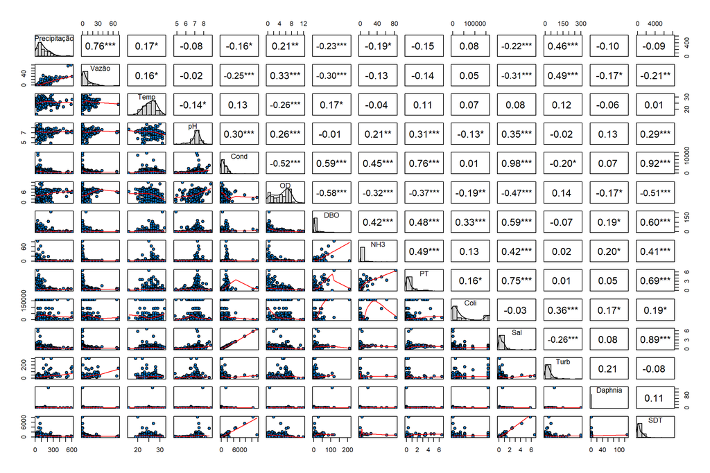

```r
pairs.panels(
  dados_chuvoso[,9:22],
  method = "spearman",
  pch = 21,
  bg = c("#0073C2FF", "#EFC000FF")[factor(dados_chuvoso$Periodo_real)],
  hist.col = "lightgray",
  density = TRUE,
  ellipses = FALSE,
  stars = TRUE,
  scale = FALSE,
  cex.cor = 1,
  cex.labels = 1.1
)
```

### 4.2 Período Seco

O mesmo procedimento anterior, mas agora filtrando os dados para o período seco

#### 4.2.1 Filtrar dados e renomear colunas, se necessário

```r
dados_seco <- dados %>%
  filter(Estacao != "IP-97",
         Periodo_real == "Seco") %>%
  rename("Precipitação" = "Precip_media",
         "Vazão" = "Vazao_media")
```

#### 4.2.2 Gerar gráfico

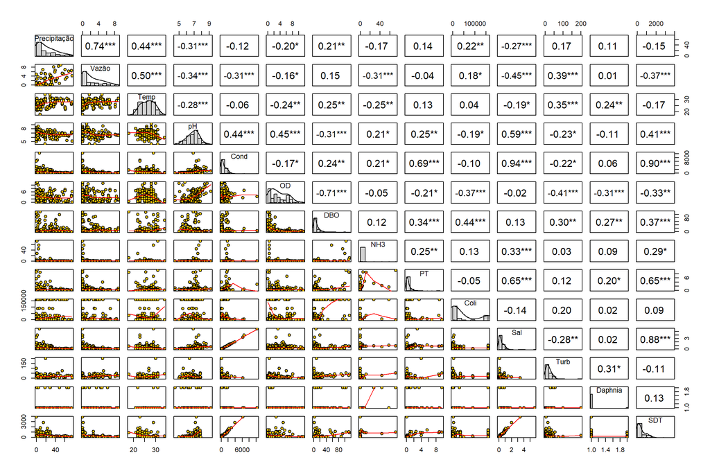

```r
pairs.panels(
  dados_seco[,9:22],
  method = "spearman",
  pch = 21,
  bg = c("#EFC000FF", "#0073C2FF")[factor(dados_seco$Periodo_real)],
  hist.col = "lightgray",
  density = TRUE,
  ellipses = FALSE,
  stars = TRUE,
  scale = FALSE,
  cex.cor = 1,
  cex.labels = 1.1
)
```

## 5. Considerações Finais

- Verifique ausências (NA) nas variáveis.
- Ajuste o intervalo `[,9:22]` conforme seu banco de dados.
- Correlação ≠ causalidade.